# Probability

Yeedle

February 1, 2017

# Wed, Feb 1

Calculators: Ti 30xs multiview Textbook: First Course in Prob. by Ross

## Counting!

A set is a collection of objects. Some examples of sets are $A= \{all~students~in~this~room\}$, $B= \{1, 2 ,3 ,4\}$, or $C = \{x |~x>5,x~integer\}$.

We denote elements of a set as $x\in A$. This means $x$ is an element of set $A$. $x\not{\in}A$ means $x$ is not an elemment of set $A$.

The union of two sets is denoted like such $A\cup B$. It means all the elements that are in one of the two sets. $x\in A \cup B$ means that $x$ is either an element of $A$ or an element of $B$ or an elemeent of both.

Sets can be subsets of other sets, denoted $A\subset B$. this means that every element in $A$ is in $B$.

(proper subsets igonred…)

$A = B$ if $B \subset A$ and $A \subset B$

Intersections, denoted $A \cap B$ is the set of elements that are in $A$ and in $B$

$x\in A \cap B$ implies $x\in A$ and $x\in B$

The universal set is everthing: $U$. this is the totality of all elements under consideration.

The complement of a set $A$ is all the elements not in $A$. There are 3 ways to write it: $\bar A$, $A^c$, and $A'$. We’ll use $\bar A$.

$A \cup \bar{A} = U$. The empty (or null) set contains no elements and is written as $\phi$ or $\varnothing$.

So $A \cap \bar{A} = \varnothing$. If we have to sets where the intersection is the null set, it means these no common elements. This is called “disjointed” sets. In probability, this is known as “mutually exclusive”.

Example (venn diagrams):

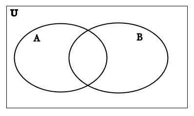

The square is the $U$ set, The overlapping area is $A \cap B$. On the other hand, everything inside the two circles is $A \cup B$.

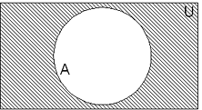

Everything outside the circle is $\bar A$

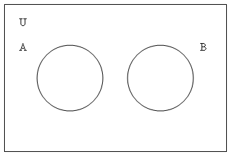

If there’s no overlap then they are disjoint, a.k.a mutually exclusive. **WARNING:** Be aware that two sets that are disjoint are definitely dpendent on each other.